# R 고급 통계분석 2일차 (4)

Sanghoo Yoon

# 주성분분석

차원축소(dimensionality reduction)와 변수추출(feature extraction) 기법으로 널리 사용

## 기법 개요

PCA는 데이터의 분산(variance)을 최대한 보존하면서 서로 직교하는 새 기저(축)를 찾아, 고차원 공간의 표본들을 선형 연관성이 없는 저차원 공간으로 변환하는 기법입니다.

PCA의 목적은 바로 이런 축을 찾는 데 있습니다.

## 주성분이란

모평균벡터와 모공분산행렬(상관행렬)을 가진 벡터가 선형결합이나

회전변환을 통해 새로운 좌표측을 형성

새로운 축은 데이터의 변동을 최대로 설명해주고, 공분산 구조(상관 구조)에 대한 해석을 용이

## PCA의 절차

1. 기존 데이터 X의 공분산행렬 계산
2. 공분산행렬의 고유값과 고유벡터 계산
3. 고유값의 크기 순서대로 고유벡터를 나열
4. 정렬된 고유벡터 가운데 일부 선택
5. 해당 고유벡터와 X 내적

PCA는 서로 직교하는 새 기저로 데이터를 변환하기 때문에 변수 간 상관관계가 높은 데이터에 효과적

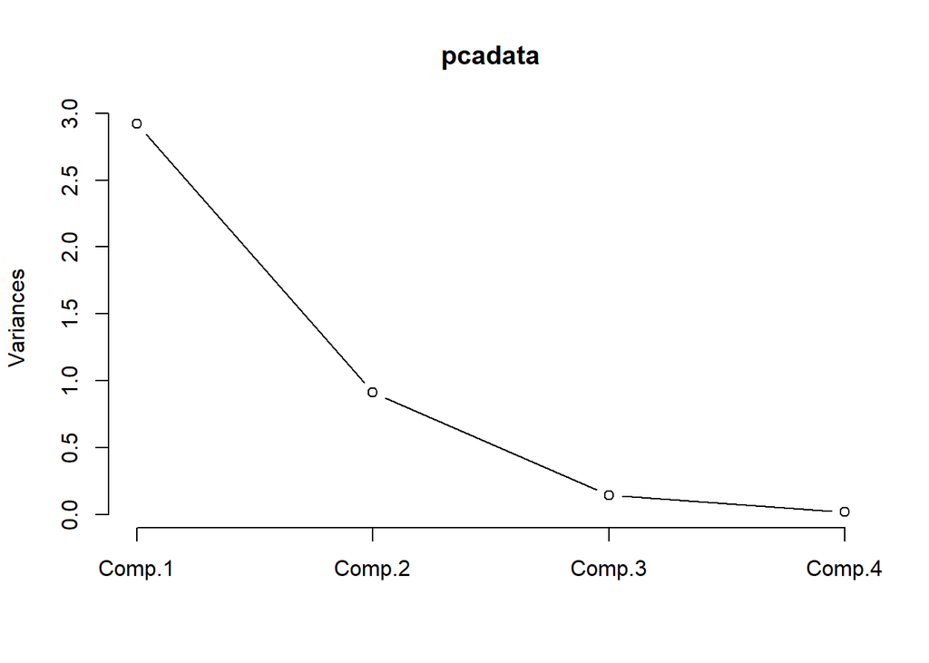

```r
pcadata <- princomp(iris[,1:4], cor=T)

# summary
plot(pcadata, type='l')
```

```r
summary(pcadata)
```

```
## Importance of components:
##                           Comp.1    Comp.2     Comp.3      Comp.4
## Standard deviation     1.7083611 0.9560494 0.38308860 0.143926497
## Proportion of Variance 0.7296245 0.2285076 0.03668922 0.005178709
## Cumulative Proportion  0.7296245 0.9581321 0.99482129 1.000000000
```